# Plots

## UPC

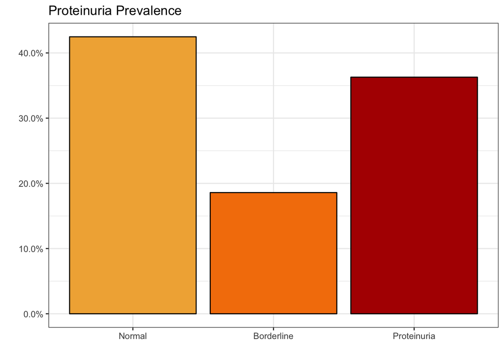

| protein | percent |
| --- | --- |
| Normal | 42.47788 |
| Borderline | 18.58407 |
| Proteinuria | 36.28319 |

Aquí només ensenyo la proporció dels nivells de proteinuria.

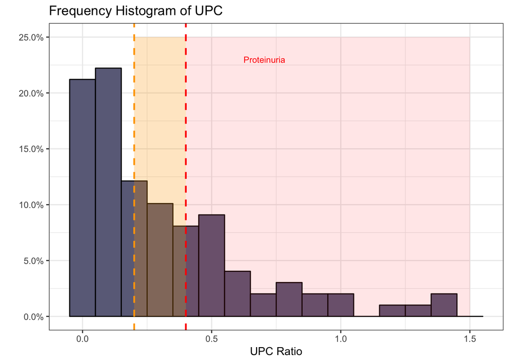

Aquest segon plot és una visió més detallada de l’anterior. Bàsicament tens la distribució dels nivells de UPCR. He pintat en taronja la zona `borderline` (entre 0.2 i 0.4) i en vermell la que he catalogat de `Proteinuria` (superior a 0.4).

## Weight

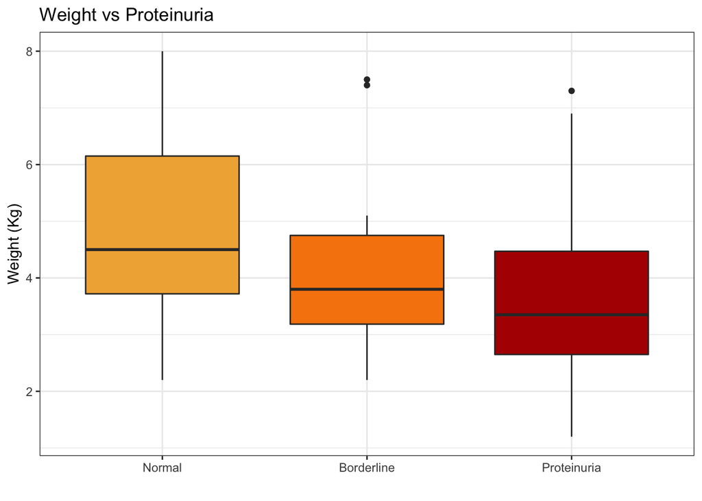

| protein | weight_mean | weight_sd |
| --- | --- | --- |
| Normal | 4.826471 | 1.598382 |
| Borderline | 4.149333 | 1.572243 |
| Proteinuria | 3.700000 | 1.592207 |

Boxplot on es veu la mitja i la dispersió de les mesures de pes pels diferents nivells de proteinuria. Es veu que la proteinuria es relaciona amb menor pes.

```
## [1] "El resultat del test estadístic surt amb un p-value de 0.00546499426457086. "
```

```
## [1] "El que ens diu que la diferencia és estadísticament significativa."
```

## Age

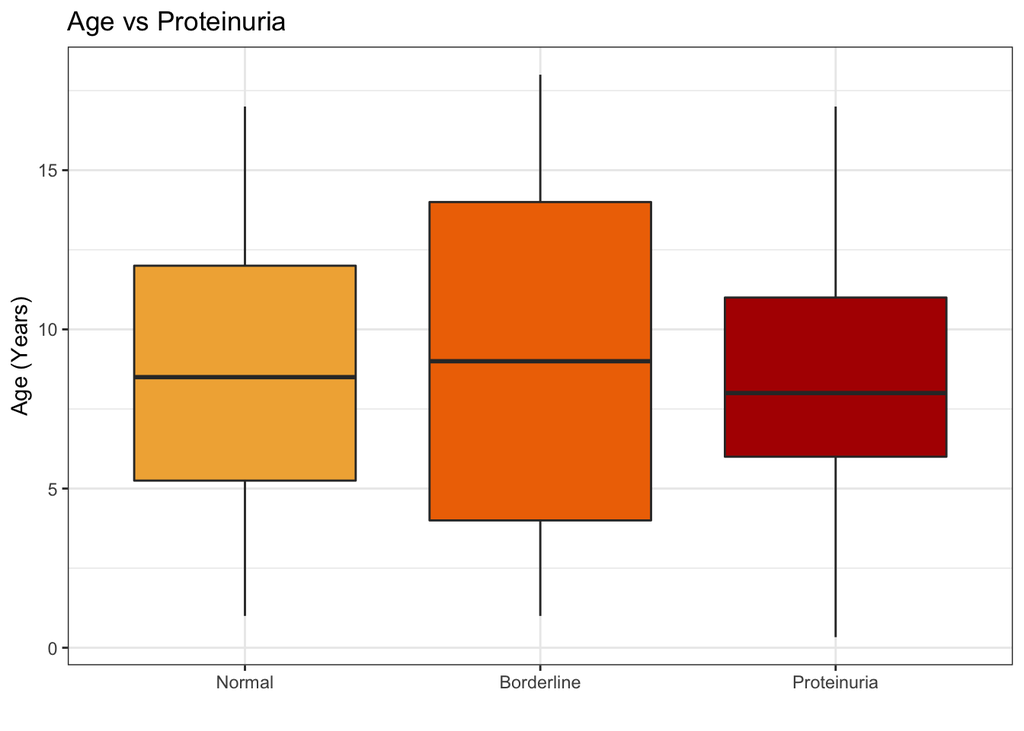

| protein | age_mean | age_sd |
| --- | --- | --- |
| Normal | 8.452381 | 4.067734 |
| Borderline | 9.117647 | 5.543942 |
| Proteinuria | 8.620833 | 4.413297 |

Aquí no cal ni un test. És evident q la proteinuria no enten d’edats. Però el fem igual

```
## [1] "El resultat del test estadístic surt amb un p-value de 0.966578679533111. "
```

```
## [1] "Per tant la diferencia NO és estadísticament significativa."
```

## Sex

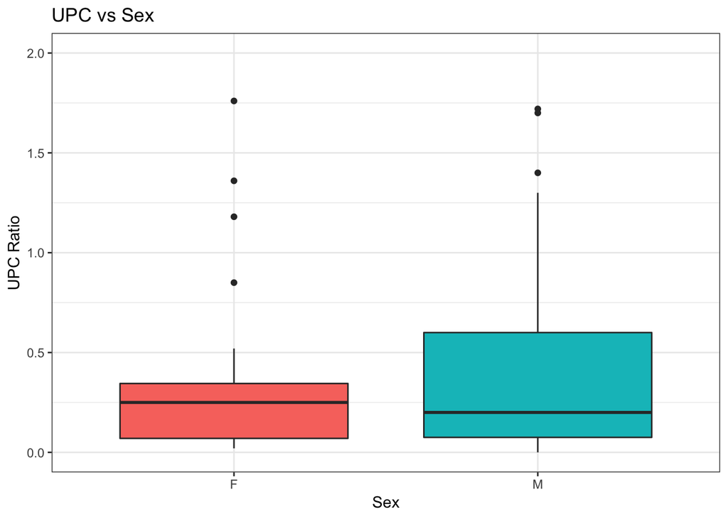

| Sex | upc_mean | upc_sd |
| --- | --- | --- |
| F | 0.7306744 | 1.7892622 |
| H | 0.5260000 | 0.8015485 |
| M | 0.4969355 | 0.6236302 |

```
## $msg1
## [1] "El resultat del test estadístic surt amb un p-value de 0.837296924075913. "
##
## $msg2
## [1] "Per tant la diferencia NO és estadísticament significativa."
```

## CKD

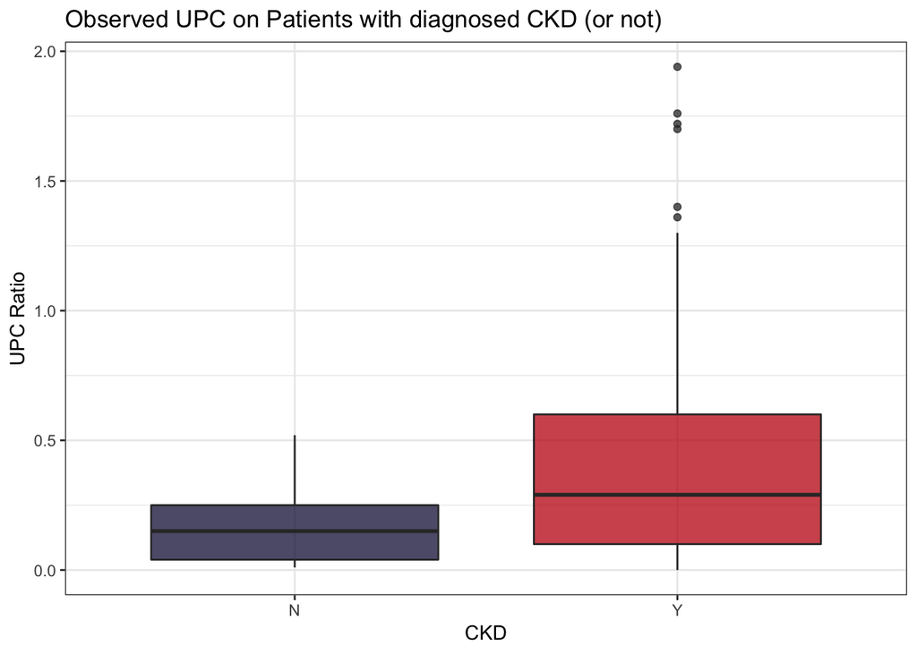

| CKD | upc_mean | upc_sd |
| --- | --- | --- |
| N | 0.2572692 | 0.4435388 |
| Y | 0.6776829 | 1.3658450 |

Aquí només mirem mitja i dispersió dels nivells de UPC mesurats, separant en pacients diagnosticats amb CKD i els que no. El que podem dir és que els pacients amb CKD diagnosticada tenen una UPC considerablement més alta (imagino que això seria prou obvi).

```
## [1] "El resultat del test estadístic surt amb un p-value de 0.0152562468054238. "
```

```
## [1] "El que ens diu que la diferencia és estadísticament significativa."
```

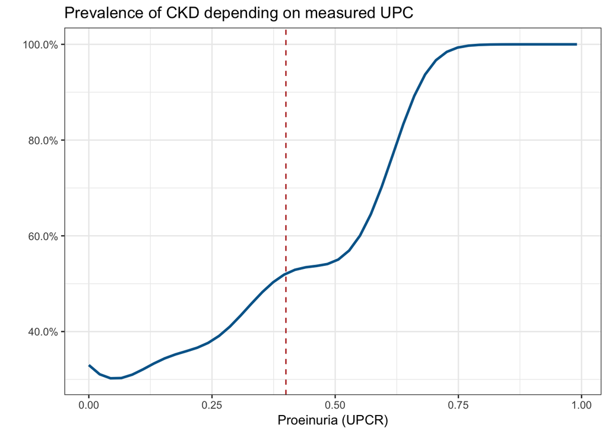

Més en detall he intentat explorar com es relaciona el nivell de UPC amb la diagnosi de CKD. El gràfic que veus ensenya el % de casos diagnosticats amb CKD en funció del UPC que presentaven. Crec que es prou rellevant que a partir de UPC superior a 0.5 es dispara cap al 100%. El que vol dir que amb proteinuria `Proteinuria` pràcticament tothom té CKD.

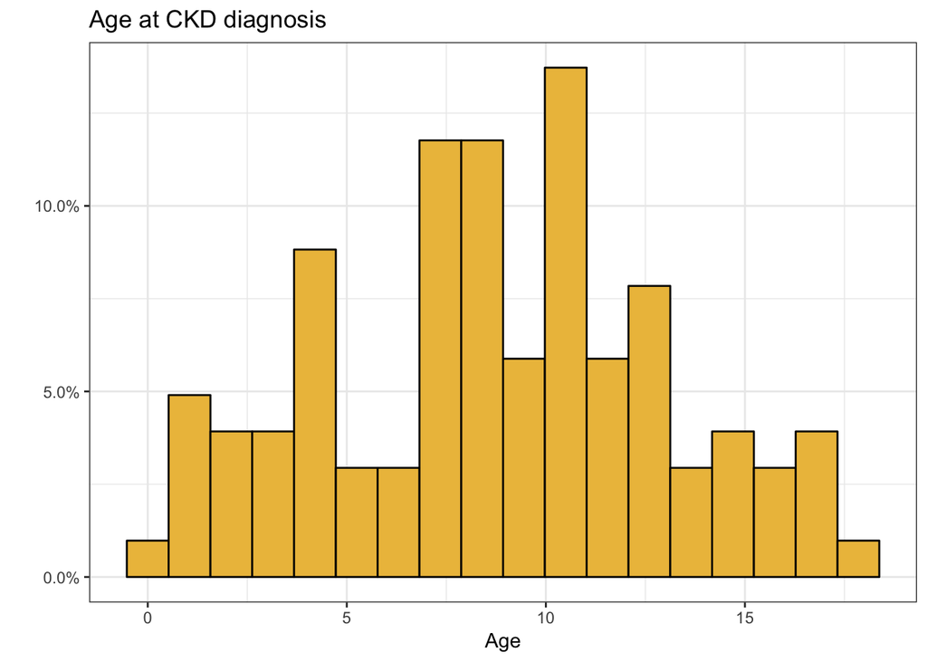

Encara imagino que això es pot estudiar més. Potser amb més dades. De moment lo que puc dir és que l’edat de diagnosi de CKD és més habitual entre els 7 i 11 anys. Però la diferencia tampoc és gaire rellevant

## Creatinina, Urea & UPC

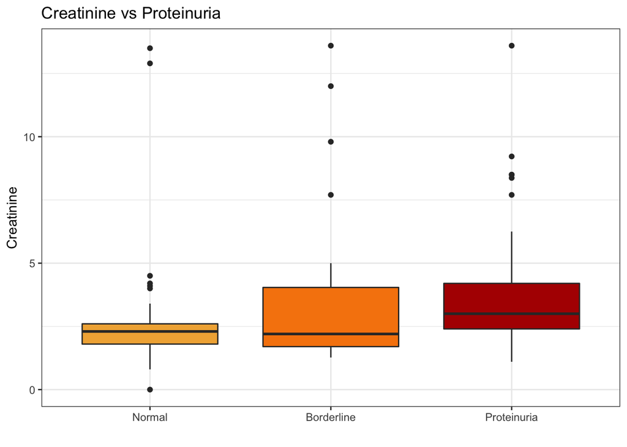

| protein | crea_mean | crea_sd |
| --- | --- | --- |
| Normal | 2.792381 | 2.524679 |
| Borderline | 3.965714 | 3.650560 |
| Proteinuria | 3.912432 | 2.739801 |

Un altre boxplot. Veiem mitja i dispersió. Sembla prou evident que amb proteinuria `Proteinuria` s’observa una *Creatinina* més alta.

```
## [1] "El resultat del test estadístic surt amb un p-value de 0.00360922660193744. "
```

```
## [1] "El que ens diu que la diferencia és estadísticament significativa."
```

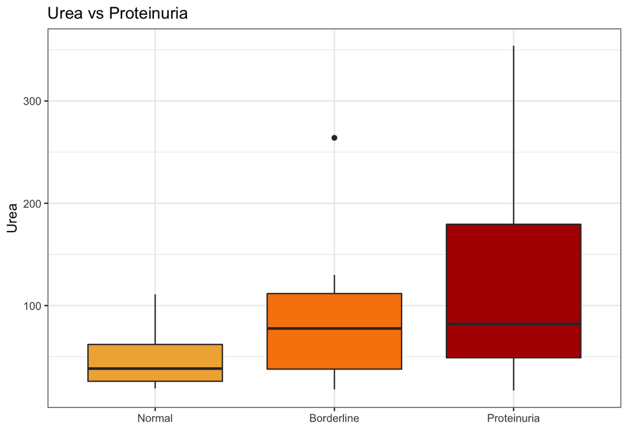

| protein | urea_mean | urea_sd |
| --- | --- | --- |
| Normal | 44.96897 | 23.25878 |
| Borderline | 82.84444 | 58.28655 |
| Proteinuria | 115.22759 | 92.09032 |

En el cas de la *Urea* observem més o menys el mateix, però en aquest cas l’impacte és molt més alt.

```
## [1] "El resultat del test estadístic surt amb un p-value de 0.000265142589688261. "
```

```
## [1] "El que ens diu que la diferencia és estadísticament significativa."
```

## Clinical Signs

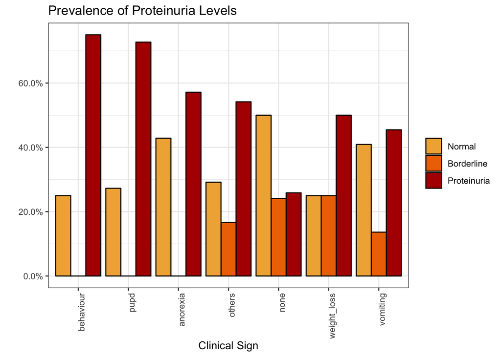

| protein | variable | value |
| --- | --- | --- |
| Proteinuria | behaviour | 0.7500000 |
| Proteinuria | pupd | 0.7272727 |
| Proteinuria | anorexia | 0.5714286 |
| Proteinuria | others | 0.5416667 |
| Normal | none | 0.5000000 |
| Proteinuria | weight_loss | 0.5000000 |
| Proteinuria | vomiting | 0.4545455 |
| Normal | anorexia | 0.4285714 |
| Normal | vomiting | 0.4090909 |
| Normal | others | 0.2916667 |

[output cut: 11 more lines]

Aquí m’he posat a investigar com podem relacionar els diferents *Clinical Signs* amb els nivells de proteinuria. Per tal que les dades tinguessin algun sentit. He reduit i agrupat moltes de les descripcions que es donàven en supergrups. Per exemple, he agrupat totes les descripcions com “accute vomiting” o “chronic vomiting” en la super-categoria “vomiting”. Sé que els detalls que es perden podrien dir coses interesants, però sense agrupar les descripcions tenim 100 *Clinical Signs* diferents per 100 pacients. Et passaré la llista de totes les agrupacions fetes, si hi ha alguna que voleu canviar, no em costa res ja. De moment ho he agrupat una mica com m’ha semblat.

FYI: El símptoma que he etiquetat com `behaviour` agrupa tot allò on a la descripció deia que l’animal es comportava estrany (lethargic, excited, weird behaviour, etc.)

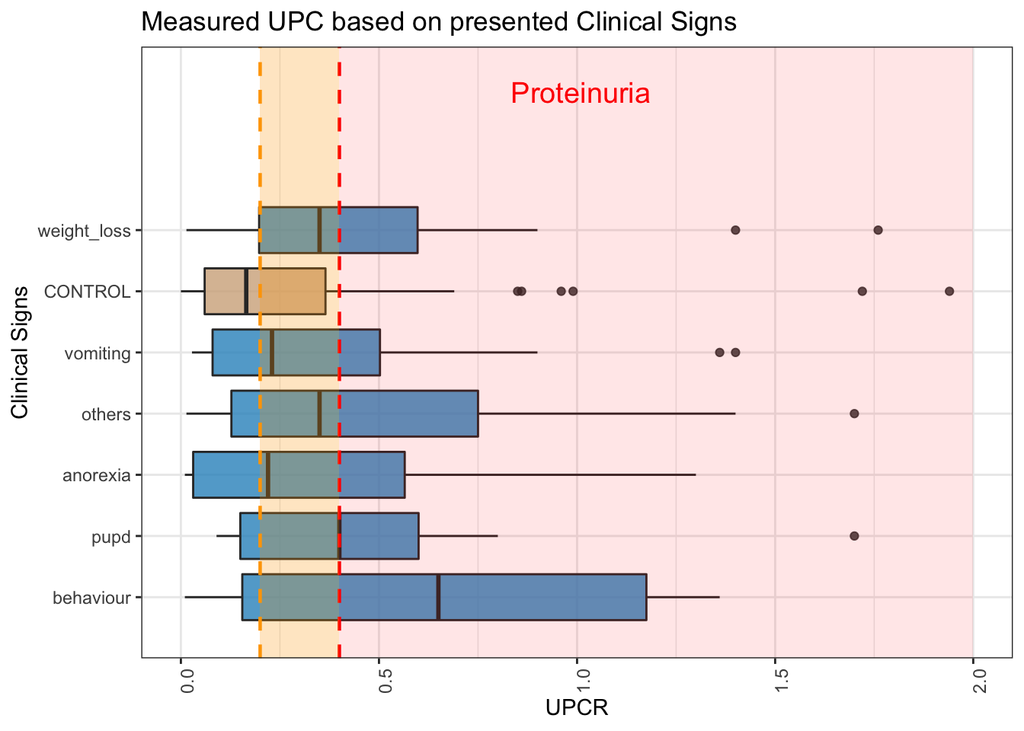

| variable | upc_mean | upc_sd |
| --- | --- | --- |
| anorexia | 0.7625714 | 1.0653542 |
| behaviour | 1.0550000 | 0.8734169 |
| none | 0.5535690 | 1.5352758 |
| pupd | 0.8600000 | 0.8600233 |
| vomiting | 0.5794545 | 0.7659882 |
| weight_loss | 0.5008750 | 0.4951083 |
| others | 0.6592500 | 0.6886511 |

Semblant al gràfic anterior, però més detallat. Intento veure com els *Clinical Signs* que es presenten poden servir per “predir” el nivell de UPC que l’animal presentaria. He fet servir l’absència de cap símptoma (controls rutinaris o coses així) com a grup `control`. Digueu-me si això té sentit. Ho he posat per tenir una referènecia.

```
## [1] 0.01177664
```

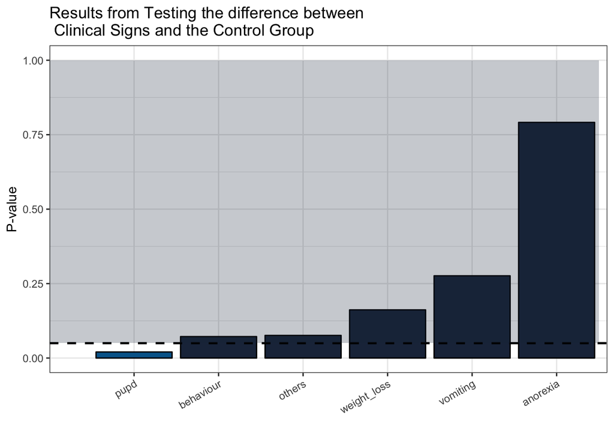

PUPD = ‘Polyuria-Polydipsia’ Presenta evidencia per si sol. Els gats amb aquests símptomes tenen més probabilitts de tenir proteinuria.

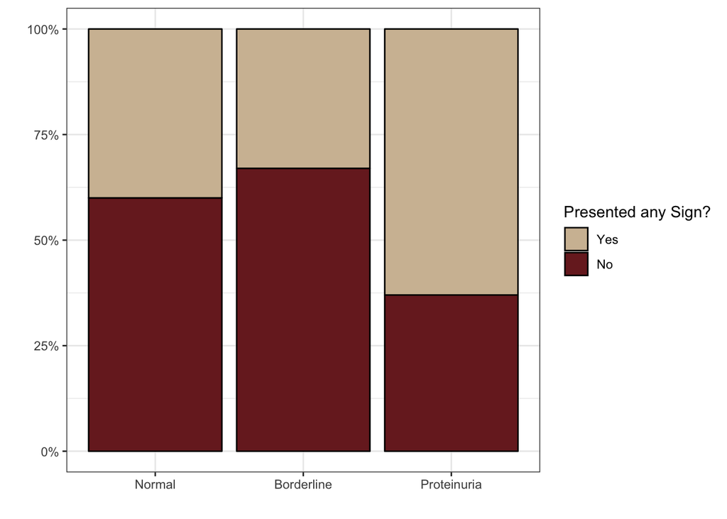

| protein | n |
| --- | --- |
| Normal | 0.40 |
| Borderline | 0.33 |
| Proteinuria | 0.63 |

```
##
##  Pearson's Chi-squared test
##
## data:  .
## X-squared = 7.4947, df = 3, p-value = 0.0577
```

Aquest altre plot el que reflexa és tal qual quin percentatge de proeinurics presentàven cap signe clínic. A diferencia de normals i borderlines, la majoria dels proteinúrics presentàven almenys algun signe clínic, el q fos.

### Table

| Clinical Signs | Borderline | Normal | Proteinuria |
| --- | --- | --- | --- |
| anorexia | 0 | 3 | 4 |
| behaviour | 0 | 2 | 6 |
| CONTROL | 14 | 29 | 15 |
| others | 4 | 7 | 13 |
| pupd | 0 | 3 | 8 |
| vomiting | 3 | 9 | 10 |
| weight_loss | 4 | 4 | 8 |

Taula comptant el nombre de Borderlines, proteinurics i ‘Normals’ per cada signe clínic. El CONTROL vol dir ‘cap signe’.

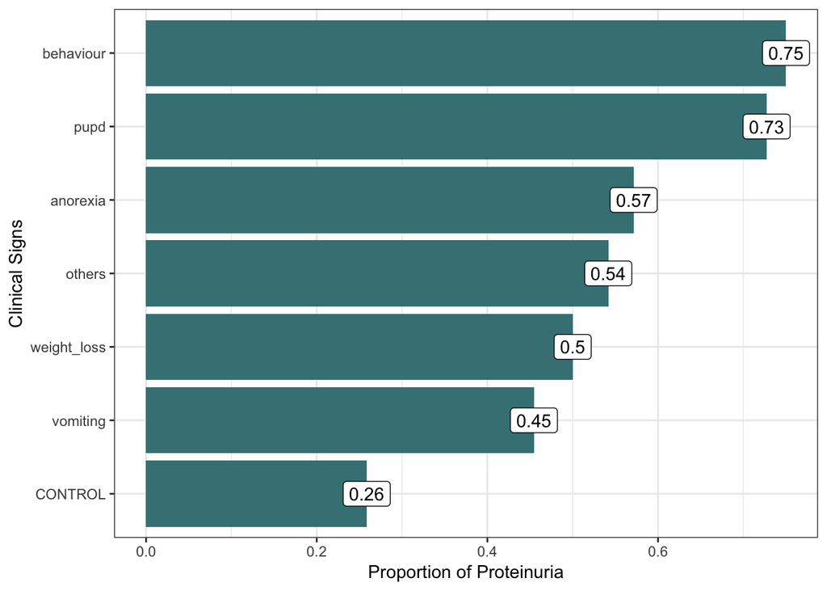

[output not shown]

Aquí he repetit el mateix exercici, però enlloc de determinar si existeix diferencia en el valor d’UPC, he estudiat la diferencia entre les proporcions de proteinurics vs no-proteinurics. Al gràfic es poden veure la proporció de proteinurics en funció dels signes clínics que presenten. A la taula es veuen els p-values del resultat de fer el test Chi-Squared a cadascun d’ells vs el CONTROL (que és sense signes clínics).

# Mortality

Ara em centraŕe en analitzar quines de les variables que tenim poden tenir cert poder predictiu per la mortalitat.

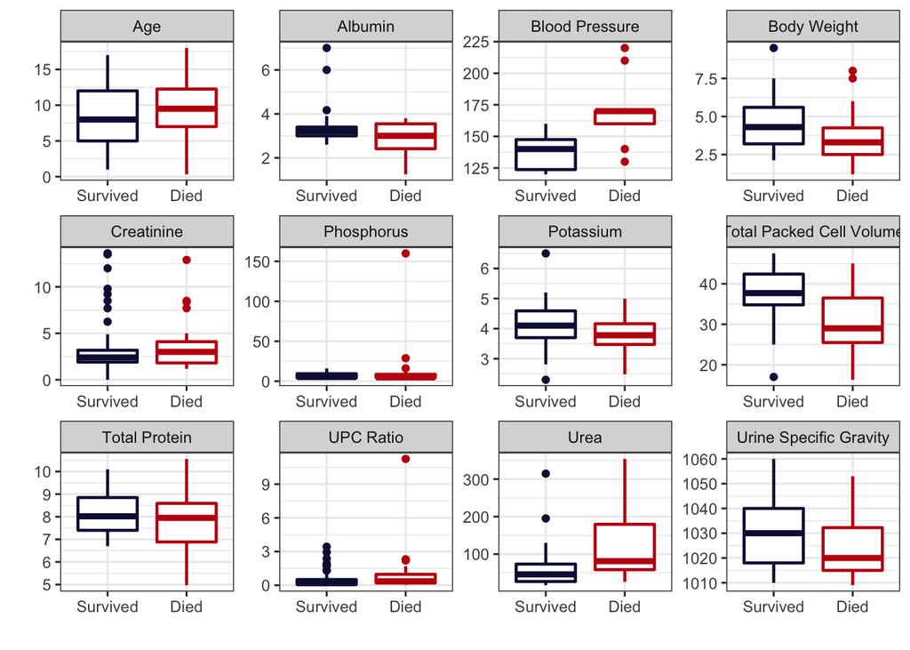

| death | variable | value_mean | value_sd |
| --- | --- | --- | --- |
| FALSE | UPCR1 | 0.4315976 | 0.6389223 |
| FALSE | PCV1 | 37.1750000 | 7.8958639 |
| FALSE | Urea1 | 61.1264151 | 51.5453279 |
| FALSE | K1 | 4.1109524 | 0.9073858 |
| FALSE | Crea_BQ1 | 3.2964103 | 2.8787014 |
| FALSE | Phos1 | 6.9978846 | 3.9921410 |
| FALSE | Weight_1 | 4.5600000 | 1.6610268 |
| FALSE | Alb_1 | 3.3417308 | 0.7300006 |
| FALSE | TP1 | 8.1548936 | 0.9036084 |
| FALSE | USG1 | 1030.0000000 | 13.4350288 |

[output cut: 14 more lines]

Per no haver-ho de fer a ull, podem fer un test estadístic a totes les comparacions.

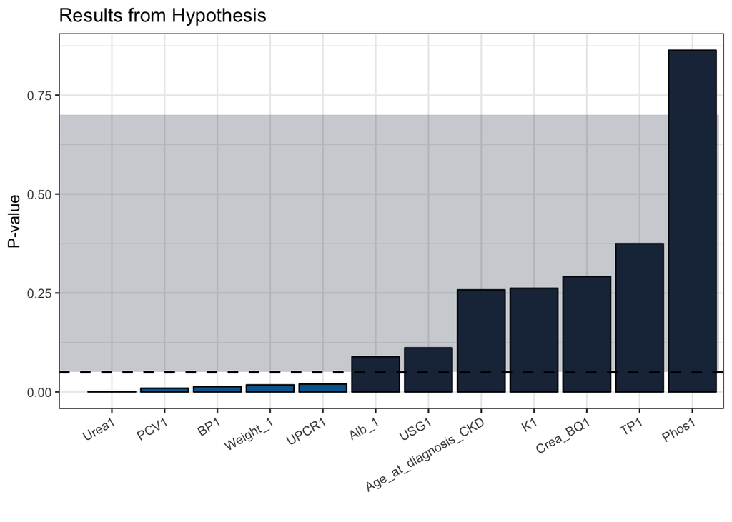

| death | variable | value_mean | value_sd | pvalues |
| --- | --- | --- | --- | --- |
| FALSE | UPCR1 | 0.4315976 | 0.6389223 | 0.0199607221 |
| FALSE | PCV1 | 37.1750000 | 7.8958639 | 0.0093310540 |
| FALSE | Urea1 | 61.1264151 | 51.5453279 | 0.0004625532 |
| FALSE | K1 | 4.1109524 | 0.9073858 | 0.2619596254 |
| FALSE | Crea_BQ1 | 3.2964103 | 2.8787014 | 0.2916696579 |
| FALSE | Phos1 | 6.9978846 | 3.9921410 | 0.8631272685 |
| FALSE | Weight_1 | 4.5600000 | 1.6610268 | 0.0176580238 |
| FALSE | Alb_1 | 3.3417308 | 0.7300006 | 0.0885634127 |
| FALSE | TP1 | 8.1548936 | 0.9036084 | 0.3747087289 |
| FALSE | USG1 | 1030.0000000 | 13.4350288 | 0.1112883782 |

[output cut: 14 more lines]

En aquest gràfic de barres podem veure el resultat del `pvalue` obtingut de tots els tests estadístics. El threshold s’ha situat a $0.05$, que és l’estàndard presentat per Fisher. El que vol dir que totes aquelles variables amb un pvalue per sota d’aquest valor, podem dir que son estadísticament significatives, pel que respecta a la mortalitat.

# Estadis CKD

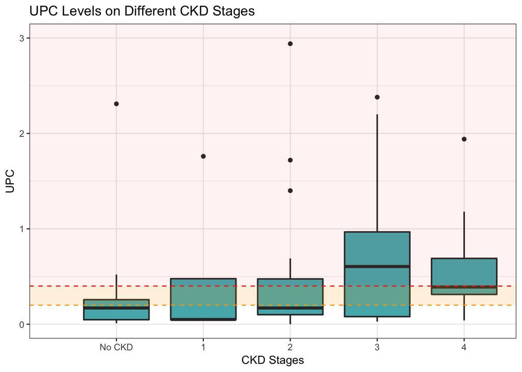

| ckd_severity | upc_mean | upc_sd |
| --- | --- | --- |
| 0 | 0.2572692 | 0.4435388 |
| 1 | 0.4750000 | 0.8566796 |
| 2 | 0.3814857 | 0.5767477 |
| 3 | 1.2003077 | 2.2194881 |
| 4 | 0.5866667 | 0.5328540 |

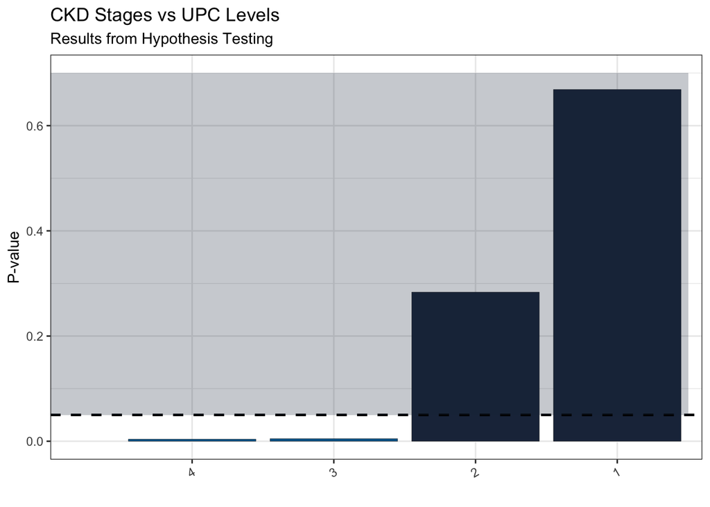

| stages | pvalue |
| --- | --- |
| 1 | 0.668779033 |
| 2 | 0.283438543 |
| 3 | 0.004795921 |
| 4 | 0.003826156 |

## CKD Stage Evolution

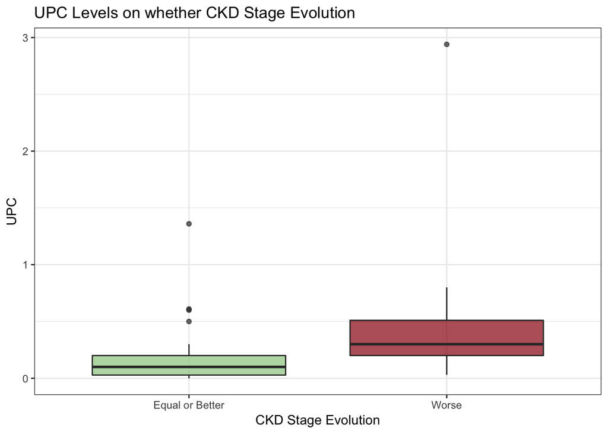

```
## [1] "El resultat del test estadístic surt amb un p-value de 0.0276483829758666. "
```

```
## [1] "El que ens diu que la diferencia és estadísticament significativa."
```

# Treatment Impact on UPC

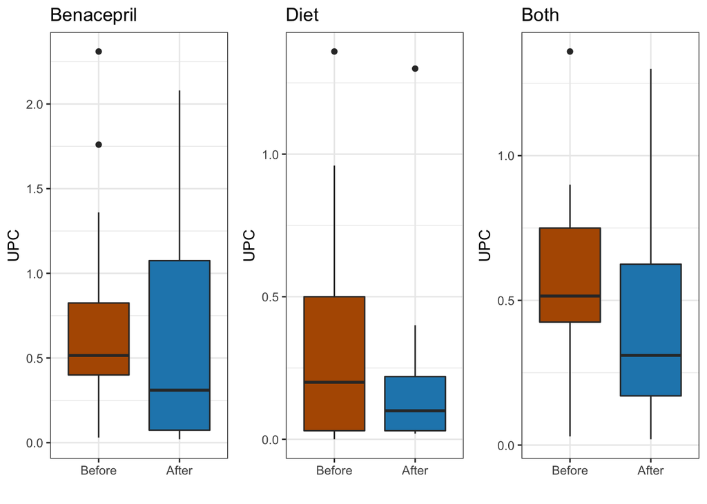

```
## [1] 0.6249765 0.3293630 0.3211329
```

## BP

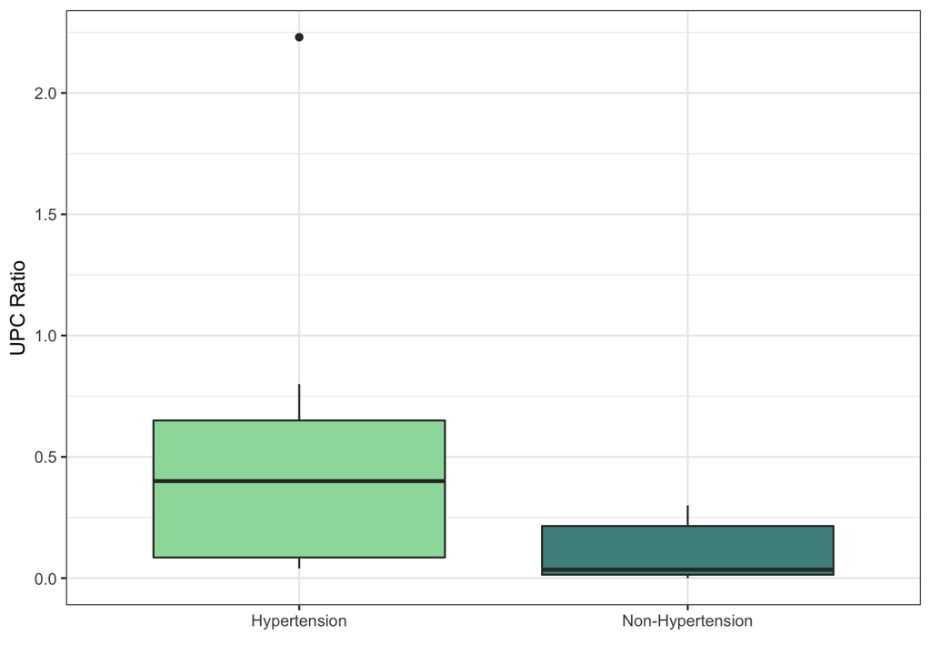

| hypertension | UPC_mean | UPC_sd |
| --- | --- | --- |
| Hypertension | 0.57625 | 0.7240351 |
| Non-Hypertension | 0.10725 | 0.1244826 |

```
##
##  Wilcoxon rank sum test with continuity correction
##
## data:  y and x
## W = 10.5, p-value = 0.02674
## alternative hypothesis: true location shift is not equal to 0
```